# Project: Creating Customer Segments

## Introduction

In this project, I'm analyzing a dataset containing data on various customers' annual spending amounts (reported in *monetary units*) of diverse product categories for internal structure.

Dataset:

- The dataset can be found on the [UCI Machine Learning Repository](https://archive.ics.uci.edu/ml/datasets/Wholesale+customers) .
- However, the features `'Channel'` and `'Region'` are excluded from the analyses.

The goals of this project are as follow:

- Describe variation in the different types of customers that a wholesale distributor interacts with
- Help the distributor identify the best delivery service to best meet the needs of each customer

The project is divided into the following parts:

- Data Exploration
  - Feature Relevance (Supervised Regression Learner)
- Data Preprocessing
  - Feature Scaling (Box-Cox test)
  - Outlier Detection ([Tukey's Method](http://datapigtechnologies.com/blog/index.php/highlighting-outliers-in-your-data-with-the-tukey-method/)) and Removal
  - PCA to discover feature that maximizes variance
  - Dimensionality Reduction using PCA to reduce complexity of the problem
- Clustering
  - Gaussian Mixture Model and KMeans
  - Identify Customer Segments hidden in the data
  - Cluster Visualization
- Conclusion
  - A/B Tests
  - Engineered Feature

```python
import numpy as np
import pandas as pd
import matplotlib.pyplot as plt
import seaborn as sns
from IPython.display import display
import renders as rs

%matplotlib inline

# Load dataset
data = pd.read_csv("./customers.csv")
data.drop(['Region', 'Channel'], axis = 1, inplace = True)

# Basic querying
print("Wholesale customers dataset has {} samples with {} features each.".format(*data.shape))
```

```
Wholesale customers dataset has 440 samples with 6 features each.
```

## Data Exploration

Attribute Information:

- FRESH: annual spending (m.u.) on fresh products (Continuous)
- MILK: annual spending (m.u.) on milk products (Continuous)
- GROCERY: annual spending (m.u.)on grocery products (Continuous)
- FROZEN: annual spending (m.u.)on frozen products (Continuous)
- DETERGENTS_PAPER: annual spending (m.u.) on detergents and paper products (Continuous)
- DELICATESSEN: annual spending (m.u.)on and delicatessen products (Continuous)

```python
data.describe()
```

|  | Fresh | Milk | Grocery | Frozen | Detergents_Paper | Delicatessen |
| --- | --- | --- | --- | --- | --- | --- |
| count | 440.000000 | 440.000000 | 440.000000 | 440.000000 | 440.000000 | 440.000000 |
| mean | 12000.297727 | 5796.265909 | 7951.277273 | 3071.931818 | 2881.493182 | 1524.870455 |
| std | 12647.328865 | 7380.377175 | 9503.162829 | 4854.673333 | 4767.854448 | 2820.105937 |
| min | 3.000000 | 55.000000 | 3.000000 | 25.000000 | 3.000000 | 3.000000 |
| 25% | 3127.750000 | 1533.000000 | 2153.000000 | 742.250000 | 256.750000 | 408.250000 |
| 50% | 8504.000000 | 3627.000000 | 4755.500000 | 1526.000000 | 816.500000 | 965.500000 |
| 75% | 16933.750000 | 7190.250000 | 10655.750000 | 3554.250000 | 3922.000000 | 1820.250000 |
| max | 112151.000000 | 73498.000000 | 92780.000000 | 60869.000000 | 40827.000000 | 47943.000000 |

### Random Sample

As usual, it's often helpful to randomly sample a few data points and explore them in more detail. The code below look at the customers that vary significantly from one another. The array `indices` below is generated after a few trials.

|  | Fresh | Milk | Grocery | Frozen | Detergents_Paper | Delicatessen |
| --- | --- | --- | --- | --- | --- | --- |
| 147 | 53.4 | 47.5 | 34.1 | 44.8 | 55.9 | 30.2 |
| 351 | 12.3 | 85.2 | 94.3 | 53.9 | 96.1 | 91.4 |
| 98 | 5.9 | 0.5 | 4.8 | 32.3 | 4.7 | 8.0 |

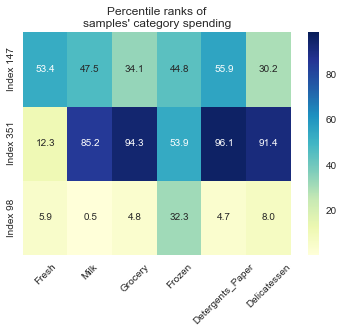

```python
# indices = (np.random.random_sample(3)*440).astype(int).tolist()
indices = [147, 351, 98]

samples = pd.DataFrame(data.loc[indices], columns = data.keys()).reset_index(drop = True)

# look at percentile ranks
pcts = 100. * data.rank(axis=0, pct=True).iloc[indices].round(decimals=3)
display(pcts)
# visualize percentiles with heatmap
sns.heatmap(pcts, yticklabels=['Index ' + str(x) for x in indices], annot=True,
 vmin=1, vmax=99, fmt='.1f', cmap='YlGnBu')
plt.title('Percentile ranks of\nsamples\' category spending')
plt.xticks(rotation=45, ha='center')
```

#### Inference

From the above, we could make the following inferences.

- Customer 147 is a restaurant. The two nonnegative values relative to the median support this argument. Restaurants do have a lot of fresh products and use more detergents and paper (table cloth, napkins, etc).
- Customer 351 is a hotel.
- Customer 98 is a small cafe or local grocery store.

### Implementation: Feature Relevance

We are now going to write code to determine if one (or more) of the six product categories is actually relevant for understanding customer purchasing behavior.

In particular, we will train a supervised regression learner on a subset of the data with one feature removed. Then, we will see how well that model can predict the removed feature.

```python
from sklearn.cross_validation import train_test_split
from sklearn.tree import DecisionTreeRegressor

for category in list(data.columns.values):
    new_data = data.drop(category, axis=1)
    X_train, X_test, y_train, y_test = train_test_split(new_data, data[category], test_size=0.25, random_state=42)
    regressor = DecisionTreeRegressor(max_depth=3, random_state=42).fit(X_train, y_train)

    score = regressor.score(X_test, y_test)
    print('{category}: {score}'.format(category=category, score=score))
```

```
Fresh: -0.28388705064962894
Milk: 0.41208337862255345
Grocery: 0.6622877471200723
Frozen: 0.04260382956145636
Detergents_Paper: 0.5800925978481628
Delicatessen: -10.204597766550537
```

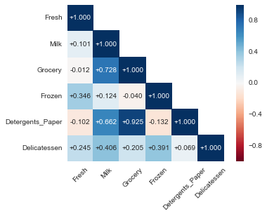

```python
corr = data.corr()
mask = np.zeros_like(corr)
mask[np.triu_indices_from(mask, 1)] = True
with sns.axes_style("white"):
    ax = sns.heatmap(corr, mask=mask, square=True, annot=True, cmap='RdBu', fmt='+.3f')
    plt.xticks(rotation=45, ha='center');
```

#### Coefficient of determination

To interpret the results above, we first need to understand what the correlation coefficient is. It is denoted by `r` and it measures the strength of the linear relationship between two variables. It takes on value between -1 and 1.

The square of `r` is called the coefficient of determination, often abbreviated as `R^2` (the square of the correlation coefficient), is the proportion of the variance in the dependent variable that is predictable from the independent variable.

`R^2` can be thought of how well a model fits the data. It takes on values between 0 and 1, where 1 is the prefect fit. A negative `R^2` implies the model fails to fit the data.

Thus, `'Grocery'` is not necessary for identifying customers' spending habits. The reasoning behind this statement is that if we knew other features of a customer, we can correctly predict how much money said customer will spend on 'Grocery' 66% of the time. In contrast, trying to predict 'Fresh' yields a negative R_2 score, which implies impossibility to predict.

#### Visualize Feature Distributions

To get a better understanding of the dataset, we can construct a scatter matrix of each of the six product features present in the data.

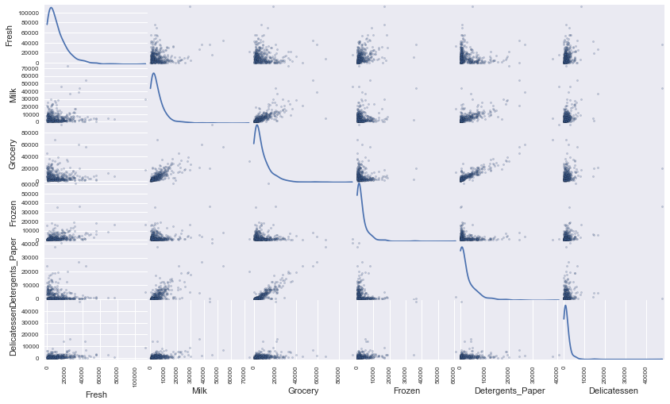

```python
pd.scatter_matrix(data, alpha = 0.3, figsize = (14,8), diagonal = 'kde');
```

The visualizations are consistent with the interpretation given under the coefficient of determination section. More precisely, we can see that the feature that is not relevant for identifying a specific customer ('Grocery') shows correlation between it and 'Detergents' in the data.

There is also correlation between 'Grocery' and 'Milk'.

## Data Preprocessing

In this section, we will create better representation of customers through feature scaling.

Additionally, we will detect and remove outliers. This step is critical in ensuring the results obtained from our analyses are meaningful.

### Feature scaling

If data is not normally distributed, especially if the mean and median vary significantly (indicating a large skew), it is most [often appropriate](http://econbrowser.com/archives/2014/02/use-of-logarithms-in-economics) to apply a non-linear scaling — particularly for financial data. One way to achieve this scaling is by using a [Box-Cox test](http://scipy.github.io/devdocs/generated/scipy.stats.boxcox.html), which calculates the best power transformation of the data that reduces skewness. A simpler approach which can work in most cases would be applying the natural logarithm.

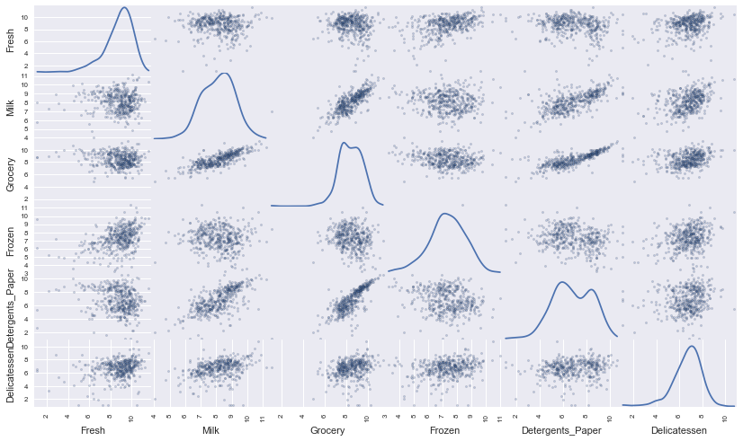

```python
log_data = np.log(data)
log_samples = np.log(samples)
pd.scatter_matrix(log_data, alpha = 0.3, figsize = (14,8), diagonal = 'kde');
```

### Observation

After applying a natural logarithm scaling to the data, the distribution of each feature appear much more normal.

If we look at our the pairs which were identified to be correlated earlier on, namely, (Milk, Grocery) and (Grocery, Detergents_Paper), we can see that they remain correlated.

**Hence, scaling our features hasn't caused us to lose any important information about our data!**

```python
display(log_samples)
```

|  | Fresh | Milk | Grocery | Frozen | Detergents_Paper | Delicatessen |
| --- | --- | --- | --- | --- | --- | --- |
| 0 | 9.127285 | 8.123558 | 7.903596 | 7.159292 | 6.986566 | 6.265301 |
| 1 | 7.098376 | 9.214731 | 10.012073 | 7.462215 | 9.444463 | 8.051022 |
| 2 | 6.220590 | 4.718499 | 6.656727 | 6.796824 | 4.025352 | 4.882802 |

### Outlier Detection

As mentioned earlier, the presence of outliers can skew results of analyses. Here, we are going to use Tukey's method to identify outliers.

In the method, an outlier step is calculated as 1.5 times the interquartile range and a data point lying beyond the outlier step is considered abnormal.

Essentially, the code below tries to find data points with extreme (high/low) values.

```python
from collections import defaultdict

d = defaultdict(int)
for feature in log_data.keys():
    Q1 = np.percentile(log_data[feature], 25.0)
    Q3 = np.percentile(log_data[feature], 75.0)
    step = 1.5*(Q3-Q1)

    # Display the outliers
    print("Data points considered outliers for the feature '{}':".format(feature))
    # Series object
    a = ~((log_data[feature] >= Q1 - step) & (log_data[feature] <= Q3 + step))
    for i in log_data[a].index:
        d[i] += 1
    display(log_data[a])

outliers  = list({k:v for k,v in d.items() if v > 1}.keys())

# Remove the outliers
good_data = log_data.drop(log_data.index[outliers]).reset_index(drop = True)
```

```
Data points considered outliers for the feature 'Fresh':
```

|  | Fresh | Milk | Grocery | Frozen | Detergents_Paper | Delicatessen |
| --- | --- | --- | --- | --- | --- | --- |
| 65 | 4.442651 | 9.950323 | 10.732651 | 3.583519 | 10.095388 | 7.260523 |
| 66 | 2.197225 | 7.335634 | 8.911530 | 5.164786 | 8.151333 | 3.295837 |
| 81 | 5.389072 | 9.163249 | 9.575192 | 5.645447 | 8.964184 | 5.049856 |
| 95 | 1.098612 | 7.979339 | 8.740657 | 6.086775 | 5.407172 | 6.563856 |
| 96 | 3.135494 | 7.869402 | 9.001839 | 4.976734 | 8.262043 | 5.379897 |
| 128 | 4.941642 | 9.087834 | 8.248791 | 4.955827 | 6.967909 | 1.098612 |
| 171 | 5.298317 | 10.160530 | 9.894245 | 6.478510 | 9.079434 | 8.740337 |
| 193 | 5.192957 | 8.156223 | 9.917982 | 6.865891 | 8.633731 | 6.501290 |
| 218 | 2.890372 | 8.923191 | 9.629380 | 7.158514 | 8.475746 | 8.759669 |
| 304 | 5.081404 | 8.917311 | 10.117510 | 6.424869 | 9.374413 | 7.787382 |
| 305 | 5.493061 | 9.468001 | 9.088399 | 6.683361 | 8.271037 | 5.351858 |
| 338 | 1.098612 | 5.808142 | 8.856661 | 9.655090 | 2.708050 | 6.309918 |
| 353 | 4.762174 | 8.742574 | 9.961898 | 5.429346 | 9.069007 | 7.013016 |
| 355 | 5.247024 | 6.588926 | 7.606885 | 5.501258 | 5.214936 | 4.844187 |
| 357 | 3.610918 | 7.150701 | 10.011086 | 4.919981 | 8.816853 | 4.700480 |
| 412 | 4.574711 | 8.190077 | 9.425452 | 4.584967 | 7.996317 | 4.127134 |

```
Data points considered outliers for the feature 'Milk':
```

|  | Fresh | Milk | Grocery | Frozen | Detergents_Paper | Delicatessen |
| --- | --- | --- | --- | --- | --- | --- |
| 86 | 10.039983 | 11.205013 | 10.377047 | 6.894670 | 9.906981 | 6.805723 |
| 98 | 6.220590 | 4.718499 | 6.656727 | 6.796824 | 4.025352 | 4.882802 |
| 154 | 6.432940 | 4.007333 | 4.919981 | 4.317488 | 1.945910 | 2.079442 |
| 356 | 10.029503 | 4.897840 | 5.384495 | 8.057377 | 2.197225 | 6.306275 |

```
Data points considered outliers for the feature 'Grocery':
```

|  | Fresh | Milk | Grocery | Frozen | Detergents_Paper | Delicatessen |
| --- | --- | --- | --- | --- | --- | --- |
| 75 | 9.923192 | 7.036148 | 1.098612 | 8.390949 | 1.098612 | 6.882437 |
| 154 | 6.432940 | 4.007333 | 4.919981 | 4.317488 | 1.945910 | 2.079442 |

```
Data points considered outliers for the feature 'Frozen':
```

|  | Fresh | Milk | Grocery | Frozen | Detergents_Paper | Delicatessen |
| --- | --- | --- | --- | --- | --- | --- |
| 38 | 8.431853 | 9.663261 | 9.723703 | 3.496508 | 8.847360 | 6.070738 |
| 57 | 8.597297 | 9.203618 | 9.257892 | 3.637586 | 8.932213 | 7.156177 |
| 65 | 4.442651 | 9.950323 | 10.732651 | 3.583519 | 10.095388 | 7.260523 |
| 145 | 10.000569 | 9.034080 | 10.457143 | 3.737670 | 9.440738 | 8.396155 |
| 175 | 7.759187 | 8.967632 | 9.382106 | 3.951244 | 8.341887 | 7.436617 |
| 264 | 6.978214 | 9.177714 | 9.645041 | 4.110874 | 8.696176 | 7.142827 |
| 325 | 10.395650 | 9.728181 | 9.519735 | 11.016479 | 7.148346 | 8.632128 |
| 420 | 8.402007 | 8.569026 | 9.490015 | 3.218876 | 8.827321 | 7.239215 |
| 429 | 9.060331 | 7.467371 | 8.183118 | 3.850148 | 4.430817 | 7.824446 |
| 439 | 7.932721 | 7.437206 | 7.828038 | 4.174387 | 6.167516 | 3.951244 |

```
Data points considered outliers for the feature 'Detergents_Paper':
```

|  | Fresh | Milk | Grocery | Frozen | Detergents_Paper | Delicatessen |
| --- | --- | --- | --- | --- | --- | --- |
| 75 | 9.923192 | 7.036148 | 1.098612 | 8.390949 | 1.098612 | 6.882437 |
| 161 | 9.428190 | 6.291569 | 5.645447 | 6.995766 | 1.098612 | 7.711101 |

```
Data points considered outliers for the feature 'Delicatessen':
```

|  | Fresh | Milk | Grocery | Frozen | Detergents_Paper | Delicatessen |
| --- | --- | --- | --- | --- | --- | --- |
| 66 | 2.197225 | 7.335634 | 8.911530 | 5.164786 | 8.151333 | 3.295837 |
| 109 | 7.248504 | 9.724899 | 10.274568 | 6.511745 | 6.728629 | 1.098612 |
| 128 | 4.941642 | 9.087834 | 8.248791 | 4.955827 | 6.967909 | 1.098612 |
| 137 | 8.034955 | 8.997147 | 9.021840 | 6.493754 | 6.580639 | 3.583519 |
| 142 | 10.519646 | 8.875147 | 9.018332 | 8.004700 | 2.995732 | 1.098612 |
| 154 | 6.432940 | 4.007333 | 4.919981 | 4.317488 | 1.945910 | 2.079442 |
| 183 | 10.514529 | 10.690808 | 9.911952 | 10.505999 | 5.476464 | 10.777768 |
| 184 | 5.789960 | 6.822197 | 8.457443 | 4.304065 | 5.811141 | 2.397895 |
| 187 | 7.798933 | 8.987447 | 9.192075 | 8.743372 | 8.148735 | 1.098612 |
| 203 | 6.368187 | 6.529419 | 7.703459 | 6.150603 | 6.860664 | 2.890372 |
| 233 | 6.871091 | 8.513988 | 8.106515 | 6.842683 | 6.013715 | 1.945910 |
| 285 | 10.602965 | 6.461468 | 8.188689 | 6.948897 | 6.077642 | 2.890372 |
| 289 | 10.663966 | 5.655992 | 6.154858 | 7.235619 | 3.465736 | 3.091042 |
| 343 | 7.431892 | 8.848509 | 10.177932 | 7.283448 | 9.646593 | 3.610918 |

However, why should we remove these outliers?

Recall that we are eventually trying to create customer segments using clustering algorithms like K-Means. Further recall that K-Means tries to optimize the sum of squares. Thus, a large deviation (such as of an outlier) gets a lot of weight in K-Means and will affect our results.

## Feature Transformation

In this section we will use principal component analysis (PCA) to draw conclusions about the underlying structure of the wholesale customer data.

Since using PCA on a dataset calculates the dimensions which best maximize variance, we will find which compound combinations of features best describe customers.

Now that the data has been scaled to a more normal distribution and has had any necessary outliers removed, we can now apply PCA to the good_data to discover which dimensions about the data best maximize the variance of features involved.

In addition to finding these dimensions, PCA will also report the explained variance ratio of each dimension — how much variance within the data is explained by that dimension alone.

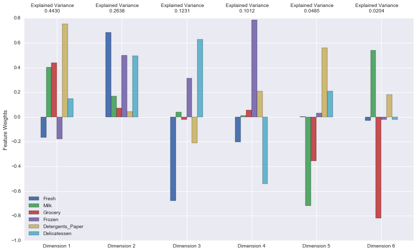

```python
from sklearn.decomposition import PCA
pca = PCA(n_components=6).fit(good_data)
pca_samples = pca.transform(log_samples)
pca_results = rs.pca_results(good_data, pca)
```

#### Analysis

The total variance in the data explained by the first and second principal components is 0.7068 and by the first four is 0.9311. Suppose that correlation value >= 0.5 is considered important.

Then, the first PC strongly correlates with detergent_papers. It increases with increasing detergent_papers and grocery and milk. This might represent spending in household staples products that are often purchased together.

The second PC correlates with strongly with fresh, frozen and delicatessen.

The third PC increases with increasing delicatessen and decreasing fresh.

The fourth PC increases with increasing frozen and decreasing delicatessen.

```python
display(pd.DataFrame(np.round(pca_samples, 4),
                     columns=pca_results.index.values))
```

|  | Dimension 1 | Dimension 2 | Dimension 3 | Dimension 4 | Dimension 5 | Dimension 6 |
| --- | --- | --- | --- | --- | --- | --- |
| 0 | -0.2001 | -0.0796 | -0.5951 | 0.0374 | 0.2117 | 0.4897 |
| 1 | 3.5620 | -0.0014 | 1.4795 | 0.3680 | 0.4277 | -0.1850 |
| 2 | -3.9943 | -3.7213 | 0.9051 | 0.3626 | 1.1423 | -0.7471 |

### Dimensionality Reduction

When using principal component analysis, one of the main goals is to reduce the dimensionality of the data — in effect, reducing the complexity of the problem. Dimensionality reduction comes at a cost: Fewer dimensions used implies less of the total variance in the data is being explained.

Because of this, the cumulative explained variance ratio is extremely important for knowing how many dimensions are necessary for the problem.

Additionally, if a signifiant amount of variance is explained by only two or three dimensions, the reduced data can be visualized afterwards.

```python
# Fitting with only two dimensions
pca = PCA(n_components=2).fit(good_data)
reduced_data = pca.transform(good_data)
pca_samples = pca.transform(log_samples)
reduced_data = pd.DataFrame(reduced_data, columns = ['Dimension 1', 'Dimension 2'])
```

```python
# Display sample log-data after applying PCA transformation in two dimensions
display(pd.DataFrame(np.round(pca_samples, 4), columns = ['Dimension 1', 'Dimension 2']))
```

|  | Dimension 1 | Dimension 2 |
| --- | --- | --- |
| 0 | -0.2001 | -0.0796 |
| 1 | 3.5620 | -0.0014 |
| 2 | -3.9943 | -3.7213 |

Observe how the values for the first two dimensions remains unchanged when compared to a PCA transformation in six dimensions!

We now know concretely that we can use just the first two dimensions/principal components!

## Clustering

We will use this unsupervised learning method to create customer segments. In particular, we can choose between GMM and KMeans.

Below are some of the tradeoffs to consider:

Speed/Scalability:

- K-Means faster and more scalable
- GMM slower due to using information about the data distribution — ie, mean, variance, covariance, assigning probabilities of points belonging to each cluster.

Cluster assignment:

- K-Means hard assignment of points to cluster (straight boundaries, assumes symmetrical spherical shapes)
- GMM soft assignment gives more structural information, including probabilities (assumes elliptical shape)

Choice: GMM. Reason: Since we have reduced dimensionality, we could use GMM to get more accurate results.

### Creating Clusters

Depending on the problem, the number of clusters that we expect to be in the data may already be known. When the number of clusters is not known a priori, there is no guarantee that a given number of clusters best segments the data, since it is unclear what structure exists in the data — if any.

However, we can quantify the "goodness" of a clustering by calculating each data point's silhouette coefficient. The silhouette coefficient for a data point measures how similar it is to its assigned cluster from -1 (dissimilar) to 1 (similar). Calculating the mean silhouette coefficient provides for a simple scoring method of a given clustering.

```python
from sklearn.mixture import GMM
from sklearn.metrics import silhouette_score

def gmm_cluster(n):
    clusterer = GMM(n_components=n).fit(reduced_data)
    preds = clusterer.predict(reduced_data)
    centers = clusterer.means_
    sample_preds = clusterer.predict(pca_samples)
    score = silhouette_score(reduced_data, preds)
    return clusterer, preds, centers, sample_preds, score
```

```python
for i in range(2, 7):
    gmm = gmm_cluster(i)
    res = "No. of clusters: {num_clusters}, Silhouette score: {score}".format(num_clusters=i, score=gmm[4])
    print(res)
```

```
No. of clusters: 2, Silhouette score: 0.41181886438624477
No. of clusters: 3, Silhouette score: 0.37513463899044264
No. of clusters: 4, Silhouette score: 0.337969395885571
No. of clusters: 5, Silhouette score: 0.29544147074709004
No. of clusters: 6, Silhouette score: 0.28528388860250026
```

### Analysis

'2' yields the highest silhouette score hence every data point, on average, is most similar to its assigned cluster.

### Cluster Visualization

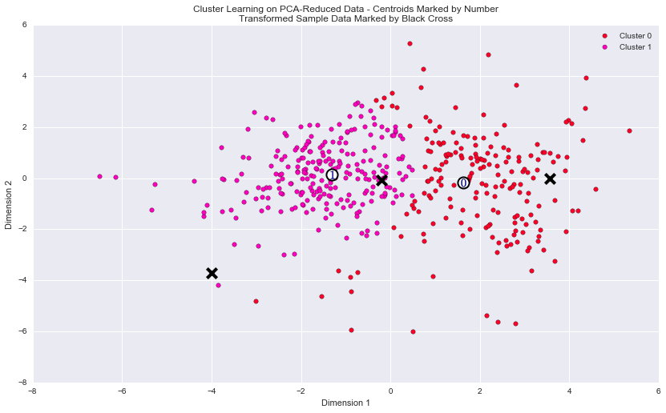

```python
# Display the results of the clustering from implementation
gmm = gmm_cluster(2)
preds = gmm[1]
centers = gmm[2]
rs.cluster_results(reduced_data, preds, centers, pca_samples)
```

## Conclusion

### A/B Tests

Companies often run A/B tests when making small changes to their products or services to determine whether that change affects its customers positively or negatively.

Suppose that the wholesale distributor wants to consider changing its delivery service from 5 days a week to 3 days a week, but will only do so if it affects their customers positively.

Question: How would you use the customer segments you found above to perform an A/B Test for this change?

Answer: For each segment, we can randomly divide the customers into control and variation groups. As implied by the names, the customers in the control group will continue to have their products delivered to them 5 days/week; customers in the variation group will get their products 3 days/week. Then, for each segment, we compute the observed significance level, a.k.a the P-value. After determining the threshold, we can conclude that the testing data support the null hypothesis if the P-value is greater than the threshold. If the P-values for both segments exceed the threshold, then, it's plausible to roll out the new delivery service to both segments. But, we can also determine the group that's affected the most from the magnitude of the P-value. The segment with greater P-value gets affected the most.

### Engineered Feature

Additional structure is derived from originally unlabelled data when using clustering techniques. Since each customer has a segment it best identifies with (depending on the clustering algorithm applied), we can consider 'customer segment' as an engineered feature for the data.

Now, if the wholesale distributor acquired new customers and had made estimates for each of the customer's annual spending of the six product categories (Fresh, Milk, Grocery, Frozen, Detergent_Papers, Delicatessen).

Knowing this estimates, we can use the 'cluster labels' as new input features to predict a customer's segment.

By performing feature engineering and using the output of an unsupervised learning analaysis as an input to a new supervised learning analysis, we can possibly predict a new customer's delivery preference without needing to A/B test them beforehand.